# Recueil et Analyse de Données par Échantillonnage

Nivaida , Marie, Grace ,Shankavi, Mariama

1. **Accéder à l’outil de recherche et remplacement** :
   - Cliquez sur l’icône en forme de **loupe** ou utilisez le raccourci clavier :
- **Mac** : `Cmd + Shift + F`
- **Windows** : `Ctrl + Shift + F`
2. **Rechercher le chemin existant** :
- Dans la barre de recherche, entrez le chemin suivant :  
  `C:/Users/DIMA/Downloads/statelite/donnees_statelite.xlsx`
3. **Remplacer par votre propre chemin** :
- Dans la barre de remplacement (généralement située juste en dessous ou à côté de la barre de recherche), insérez le chemin vers votre propre fichier. Par exemple :  
  `/Users/votre_nom_utilisateur/Documents/votre_fichier.xlsx`
4. **Lancer le remplacement** :
- Cliquez sur le bouton **Replace All** (Remplacer Tout) pour mettre à jour toutes les occurrences dans le fichier.

# Introduction

Dans le cadre de notre projet intitulé **“Recueil et analyse de données par échantillonnage ou plan d’expérience”**, nous avons exploité les données collectées par les étudiant·e·s de BUT1 sur les habitudes alimentaires des usagers du campus de Villetaneuse.  
Cette démarche a pour objectif de répondre à une problématique spécifique liée aux pratiques alimentaires de cette population, en s’appuyant sur une méthodologie rigoureuse d’analyse et d’interprétation des données.

## Cadre pour le Recueil de Données

#### Problématique Générale

La problématique générale de l’enquête est la suivante :  
**« Quelles sont les pratiques alimentaires des usagers sur le campus de Villetaneuse ? »**

#### Sous-problématique

Notre sous-problématique spécifique est :  
**« Les personnes ayant un régime alimentaire particulier (végétarien, végan, sans gluten, etc.) mangent-elles moins souvent au Crous en raison d’une inadéquation perçue entre leur régime et l’offre alimentaire proposée que celles sans régime particulier ? »**

#### Population Ciblée

La population ciblée inclut :  
- **Les étudiant·e·s**  
- **Le personnel travaillant à l’université**

Nous avons choisi des **variables d’intérêt** afin de répondre au mieux à notre problématique, ainsi que des **variables auxiliaires** pour enrichir l’analyse des résultats.

#### Variables d’Intérêt et Auxiliaires

| **Variable d’Intérêt** | **Variable Auxiliaire** | **Objectif** |
| --- | --- | --- |
| **Fréquentation du Crous** | Statut du répondant | Analyser les habitudes alimentaires des différents profils d’usagers. |
| **Avis sur la qualité nutritionnelle** | Âge des répondants | Évaluer l’adéquation perçue entre les besoins alimentaires et l’offre proposée. |
| **Fréquentation des repas maison** | Statut du répondant | Étudier les alternatives au Crous et les préférences des usagers. |

## Mode de Recueil et Contraintes

### Recueil des Données

Les données ont été collectées via un **questionnaire** distribué entre le **16 et le 31 octobre 2024**. Cette période inclut une **semaine de vacances scolaires (18-28 octobre)**, ce qui a limité l’accès à une partie de la population cible.

[figure not shown]

Diagramme de Venn

#### Population Couverte

- **Population observable** : Étudiant·e·s, personnel universitaire, et personnes de passage.
- **Population couverte** : Principalement les étudiant·e·s et le personnel universitaire présents pendant l’enquête.

#### Échantillon Obtenu

L’échantillon est majoritairement composé d’étudiant·e·s ayant un régime alimentaire particulier, avec quelques personnes de passage pour enrichir l’analyse.

## Couverture et Échantillon

### Couverture Sous-Optimale

La collecte de données a été impactée par :  
- Une **faible présence des étudiant·e·s** sur le campus pendant les vacances.  
- La **difficulté d’interroger les personnes de passage**, souvent indisponibles.

#### Répartition des Répondants

Sur un total de 1097 répondants, seulement **28** ont été interrogés pendant les vacances.

### Erreurs d’Observation et de Non-Observation

#### Erreurs de Couverture

| **Erreur** | **Impact** |
| --- | --- |
| Étudiant·e·s en vacances | Faible représentativité des étudiant·e·s ayant un régime alimentaire particulier. |
| Personnes de passage | Leur impact est limité, car leur rôle dans la problématique principale est marginal. |

#### Conséquences

- **Graves** : Une faible représentativité des étudiant·e·s ayant un régime alimentaire particulier, ce qui pourrait fausser les conclusions sur la fréquentation du Crous.
- **Moins graves** : L’impact des personnes de passage est limité en raison de leur faible influence sur la problématique principale.

# Échantillon, Estimateurs et Qualité

Dans cette partie, nous allons examiner les calculs effectués pour nos estimations. Nous détaillerons les étapes pour trois cas différents, en fonction de leur pertinence :

##Contexte et Limitations

Les données réels de la population nous ont été fournis par **le service des inscriptions administratives et des diplomes** et par **le Pôle Systèmes d’Information des Ressources Humaines et Gestion Prévisionnelle des Emplois, des Effectifs et des Compétences**.

| Categorie | Effectif |
| --- | --- |
| Distribution de la population totale |  |
| Categorie | Effectif |
| Total | 27805 |
| Sans régime | 16961 |
| Régime | 10844 |

| Categorie | Effectif |
| --- | --- |
| Distribution des étudiants dans la population |  |
| Categorie | Effectif |
| Total | 25702 |
| Sans régime | 15678 |
| Régime | 10024 |

| Categorie | Effectif |
| --- | --- |
| Distribution des PUV dans la population |  |
| Categorie | Effectif |
| Total | 2103 |
| Sans régime | 1283 |
| Régime | 820 |

##Plan simple : frequentation_crous

### Variable d’intérêt

La variable d’intérêt dans cette analyse est la fréquence moyenne de consommation d’un repas au Crous par un étudiant de l’université. Cette variable mesure à quelle fréquence les étudiants consomment des repas proposés au Crous, avec les modalités suivantes :

- 5 / Tous les jours
- 3,5 / 3 à 4 fois par semaine
- 1,5 / 1 à 2 fois par semaine
- 0 / Jamais

### Variable auxiliaire

La **variable auxiliaire** est le **statut** des usagers. Nous allons stratifier les résultats en fonction du statut, car celui-ci peut influencer la manière dont les usgers évaluent la qualité nutritionnelle des repas proposés.

Rappel Problématique : *« Les personnes ayant un régime alimentaire particulier (végétarien, végan, sans gluten, etc.) mangent-elles moins souvent au Crous en raison d’une inadéquation perçue entre leur régime et l’offre alimentaire proposée ? »*

Les résultats des analyses réalisées permettent de comparer les fréquences de repas au Crous entre les personnes ayant un régime alimentaire spécifique (régime) et celles n’ayant pas de régime particulier (non régime), nous verrons ci dessous l’approche dans un plan simple.

Nous avons ci dessous la distribution des réponses par statut dans notre échantillon :

Tableau croisé des réponses pour freq_repas_crous_num par statut

| statut | 0 | 1.5 | 3.5 | 5 | Total |
| --- | --- | --- | --- | --- | --- |
| Etu | 167 | 179 | 125 | 74 | 545 |
| Puv | 34 | 15 | 5 | 0 | 54 |
| Total général | 201 | 194 | 130 | 74 | 599 |

### Calcul de la moyenne empirique et de la variance de l’estimateur pour la fréquence des repas au CROUS

Dans cette section, nous allons calculer la **moyenne empirique** et la **variance de l’estimateur** pour la fréquence des repas au CROUS, en distinguant les groupes “avec régime” et “sans régime”.

#### Étape 1 : Moyenne empirique pour les usagers”avec régime” et “sans régime”

Moyenne empirique de la fréquentation au crous des usagers avec et sans régime alimentaire

| Moyenne_Freq | Moyenne.empirique.sans.régime |
| --- | --- |
| 1.863105 | 2.092077 |

Les résultats du plan simple montrent une différence notable dans la fréquence des repas au Crous entre les étudiants ayant un régime alimentaire spécifique et ceux sans régime particulier.

Personnes ayant un régime spécifique (ex : végétarien, végan, sans gluten) : La moyenne de consommation est de ***1.86** repas par semaine, ce qui suggère qu’ils mangent moins souvent au Crous, probablement en raison d’une inadéquation perçue entre leur régime alimentaire et les options proposées.

Personnes sans régime spécifique : La moyenne de consommation est de **2.09** repas par semaine, indiquant qu’ils fréquentent plus fréquemment le Crous.

Ces résultats suggèrent que les étudiants ayant des régimes spécifiques mangent moins souvent au Crous, probablement à cause d’une offre alimentaire jugée insuffisamment adaptée à leurs besoins nutritionnels.  
#### Étape 2 : Calcul de la variance de l’estimateur (échantillon “avec régime” et “sans régime”)

Statistiques de la fréquentation au CROUS par régime

| Regime | Moyenne.empirique | Variance |
| --- | --- | --- |
| Avec régime | 1.863105 | 0.0047469 |
| Sans régime | 2.092077 | 0.0073935 |

Les étudiants ayant un régime alimentaire spécifique (ex. végétarien, végan, sans gluten) consomment en moyenne 1.86 repas par semaine au Crous, avec une faible variance (0.0047), suggérant un comportement de consommation relativement uniforme. En revanche, ceux sans régime particulier mangent en moyenne 2.09 repas par semaine, avec une variance plus élevée (0.0074), indiquant une plus grande diversité dans les habitudes de fréquentation. Ces résultats suggèrent que les étudiants ayant des régimes spécifiques fréquentent moins souvent le Crous, probablement en raison d’une offre alimentaire perçue comme moins adaptée à leurs besoins.

###Calcul intervalle de confiance

Résultats des intervalles de confiance et moyennes

| Cas | Moyenne | IC Inférieur | IC Supérieur |
| --- | --- | --- | --- |
| Avec Régime Alimentaire | 1.86 | 1.86 | 1.87 |
| Sans Régime Alimentaire | 2.09 | 2.08 | 2.10 |

# Plan stratrifier : Avis sur la qualité nutritionnelle des produits du crous

## Variable d’intérêt

La **variable d’intérêt** dans cette analyse est l’**avis sur la qualité nutritionnelle des produits proposés au Crous (QNPDC)**. Cette variable est une évaluation des repas disponibles au Crous par les étudiants, où les répondants pouvaient choisir parmi les options suivantes :

- 4 / Très satisfaisante
- 3 / Satisfaisante
- 2 / Plutôt insatisfaisante
- 1 / Très insatisfaisante
- 0 / Je N_ar’ai pas d’avis

## Variable auxiliaire

La **variable auxiliaire** est l’**âge** des étudiants. Nous allons stratifier les résultats en fonction de l’âge, car l’âge peut influencer la manière dont les étudiants évaluent la qualité nutritionnelle des repas proposés.

## Contexte et Problématique

Cette étude explore l’impact d’un régime alimentaire particulier sur la perception de la qualité nutritionnelle des repas proposés au Crous. Peut-être que les usagers ayant un régime alimentaire ont une perception différente de la qualité nutritionnelle des produits crous ce qui les pousserais à y aller moins souvent.

Nous comparons les avis des usagers ayant un régime alimentaire spécifique avec ceux n’en ayant pas, afin de répondre à la problématique .**

### Méthodologie

Nous ne sommmes pas parvenus à faire des tranches d’âge avec R, nos tableaux pour ceux ci seront donc directement tirés de calculs d’excel.

# Plan stratfiée Calculs :

Passons maintenant aux calculs avec le plan stratifié, qui nous permettra d’analyser les différences dans la perception de la qualité nutritionnelle en tenant compte des tranches d’âge, offrant ainsi une analyse plus précise.

*Le plan stratifié permet d’analyser chaque groupe d’âge séparément, ce qui nous donne une vision plus précise et détaillée des différences entre les populations, contrairement à une analyse globale.*

## Distribution des groupes stratifiées

Distribution de la population selon les tranches d’âge et par catégorie pour les individues avec un régime alimentaire particulier.

| Catégorie | X15.24 | X25.34 | X35.44 | X45.54 | X55.64 | X65.71 | total_ar |
| --- | --- | --- | --- | --- | --- | --- | --- |
| 0 | 118 | 5 | 9 | 4 | 1 | 1 | 138 |
| 1 | 36 | 1 | 1 | 0 | 0 | 1 | 39 |
| 2 | 169 | 4 | 6 | 5 | 3 | 1 | 188 |
| 3 | 190 | 9 | 6 | 1 | 1 | 0 | 207 |
| 4 | 23 | 0 | 0 | 0 | 0 | 0 | 23 |
| total_ar | 536 | 19 | 22 | 10 | 5 | 3 | 595 |

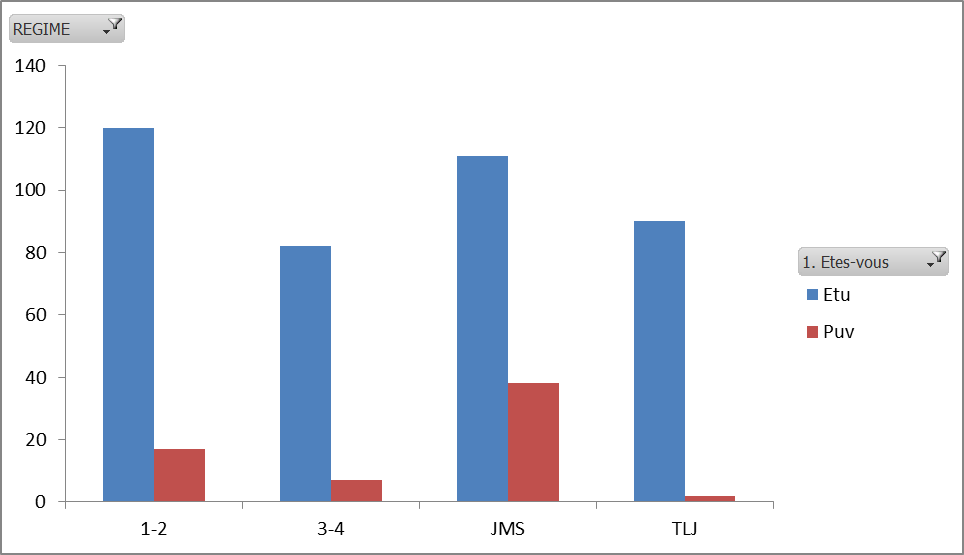

Graphique - Sans Régime Alimentaire

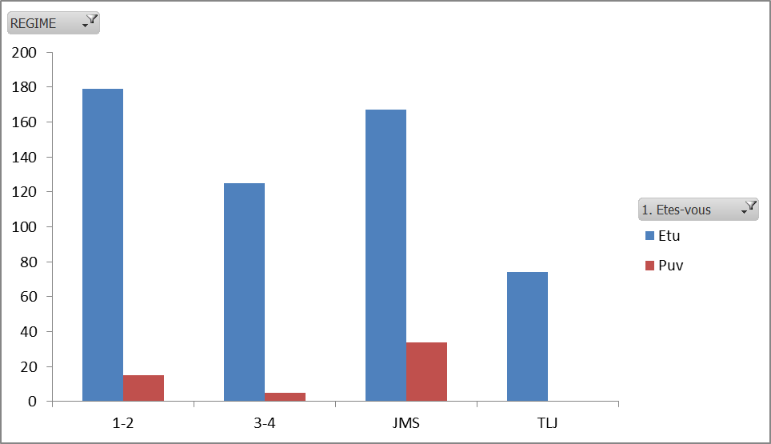

Graphique - Avec Régime Alimentaire

Distribution de la population selon les tranches d’âge et par catégorie pour les individues sans régime alimentaire particulier.

Tableau des effectifs des âges des personnes sans régime, avec les totaux par tranche d’âge et catégorie.

| Catégorie | X15.24 | X25.34 | X35.44 | X45.54 | X55.64 | X65.71 | Total |
| --- | --- | --- | --- | --- | --- | --- | --- |
| 0 | 104 | 1 | 10 | 8 | 1 | 0 | 124 |
| 1 | 28 | 2 | 3 | 1 | 0 | 0 | 34 |
| 2 | 106 | 6 | 10 | 1 | 2 | 0 | 125 |
| 3 | 142 | 11 | 10 | 3 | 2 | 0 | 168 |
| 4 | 12 | 0 | 0 | 0 | 0 | 0 | 12 |
| Total | 392 | 20 | 33 | 13 | 5 | 0 | 463 |

##Moyennes Pondérées

Pour mieux refléter la répartition réelle de la population par tranche d’âge, nous avons calculé les moyennes pondérées de la qualité nutritionnelle perçue pour chaque strate.

Moyennes pondérées par tranche d’âge et régime alimentaire

|  | Tranches d’âge Regime | Tranches d’âge X15.24 | Tranches d’âge X25.34 | Tranches d’âge X35.44 | Tranches d’âge X45.54 | Tranches d’âge X55.64 | Tranches d’âge X65.71 |
| --- | --- | --- | --- | --- | --- | --- | --- |
| X65.71 | Avec régime | 1.93 | 1.89 | 1.41 | 1.30 | 1.8 | 1 |
|  | Sans régime | 1.82 | 2.35 | 1.61 | 0.92 | 2.0 | 0 |

Moyennes stratifiées par régime alimentaire

| Regime | Moyenne.stratifiée |
| --- | --- |
| Avec régime | 1.863728 |
| Sans régime | 1.857418 |

En regroupant les moyennes pondérées de chaque tranche d’âge, on obtient les moyennes générales de la qualité nutritionnelle perçue stratifiées. Ces moyennes,sont assez proches de celles obtenues avec le plan simple,nous allons maintenant calculer la variance de ces estimateurs.

##Variances stratifiées

Statistiques par régime alimentaire

| Statistique | Avec.régime | Sans.régime |
| --- | --- | --- |
| Moyenne stratifiée | 1.8637 | 1.8574 |
| S²1 | 0.0729 | 0.0367 |
| S²2 | 0.0027 | 0.0011 |
| S²3 | 0.0037 | 0.0029 |
| S²4 | 0.0014 | 0.0035 |
| S²5 | 4e-04 | 3e-04 |
| Variance | 8.38e-05 | 4.83e-05 |

##Allocation proportionnelle Les variances obtenues pour les deux groupes, avec régime et sans régime, sont assez faibles, ce qui indique une faible dispersion des réponses autour des moyennes dans chaque groupe. Cela suggère que les répondants au sein de chaque groupe (avec ou sans régime) ont une perception relativement homogène de la qualité nutritionnelle perçue.

Nous allons maintenant appliquer une allocation proportionnelle pour estimer les moyennes pondérées de la qualité nutritionnelle perçue. Cette méthode consiste à attribuer à chaque sous-groupe (strates) une pondération basée sur sa taille relative dans la population totale. L’objectif est de “redresser” les résultats de l’échantillon afin qu’ils reflètent plus fidèlement la structure démographique réelle, notamment en tenant compte des différentes tranches d’âge et de la répartition des régimes.

Comparaison des variances selon le régime et la méthode d’allocation

| Méthode | Variance |
| --- | --- |
| Avec régime(allocation proportionelle) | 8.37e-05 |
| Sans régime(allocation proportionelle) | 5.61e-05 |

Les variances obtenues après application de l’allocation proportionnelle pour estimer la qualité nutritionnelle perçue sont relativement faibles, ce qui indique une précision plus grande dans l’estimation. Ces résultats suggèrent que l’application de l’allocation proportionnelle permet de mieux ajuster les estimations en fonction de la taille relative de chaque sous-groupe dans la population, réduisant ainsi la variance par rapport à des approches moins pondérées.

Calcul de la réduction relative de la variance Comparons maintenant les variances entre ces différents plans d’échantillonnage.

###Plan stratifié vs Plan simple

```
## Réduction relative (plan stratifié vs simple, avec régime) : 33.09 %
```

On peut en conclure que l’utilisation de d’allocation proportionnelle permet de mieux capturer la diversité des comportements dans les groupes, réduisant ainsi la variance et augmentant la précision des estimations de la qualité nutritionnelle perçue.

##Allocation optimale

Pour aller encore plus loin dans l’optimisation de l’estimation, nous allons maintenant explorer l’allocation optimale. Cette méthode permet de minimiser la variance totale en prenant en compte non seulement la taille de chaque sous-groupe, mais également la variabilité au sein de chaque strate. L’objectif est d’allouer un nombre d’observations plus important aux strates présentant une plus grande variabilité, ce qui maximise l’efficacité de l’échantillonnage.

Allocation optimale :

Comparaison des variances selon le régime et la méthode d’allocation

| Méthode | Variance |
| --- | --- |
| Avec régime(allocation Optimale) | 6.70e-05 |
| Sans régime(allocation Optimale) | 4.59e-05 |

Les résultats montrent une variance plus faible pour les deux groupes, avec et sans régime, comparativement à l’allocation proportionnelle.

###Calcul de la réduction relative de la variance (allocation optimale vs allocation proportionnelle)

Nous allons maintenant comparer la réduction de la variance entre l’allocation optimale et l’allocation proportionnelle en calculant la réduction relative de la variance pour chaque groupe.

```
## Réduction relative (allocation optimale vs proportionnelle, avec régime) : 19.95 %
```

```
## Réduction relative (allocation optimale vs proportionnelle, sans régime) : 18.18 %
```

Les résultats montrent qu’une allocation optimale permet effectivement de réduire la variance par rapport à l’allocation proportionnelle. Cette réduction significative de 20 % suggère que l’allocation optimale est une méthode utile et efficace pour améliorer la précision des estimations. Toutefois, étant donné que l’allocation proportionnelle produisait déjà des résultats avec une variance très faible, la nécessité de recourir à l’allocation optimale devient moins évidente.

#Rédressenment par post-stratification

Pour le redressement par post stratification, nous allons revenir à notre premiers cas sur la frequence du crous parce qu’il y’a un veritable lien entre le regime alimentaire et la frequentation au crous.

Nous avons décidé d’appliquer un redressement post-stratification pour cette variable en particulier, car elle répond aux trois critères nécessaires pour effectuer un tel ajustement :

```
## [1] 0.000567442
```

Grâce à nos calculs, nous avons obtenu des estimations redressées qui permettent une représentation plus précise de la population étudiée.

en effet nous obtenons , mu_post = 2.412232 et varpost_ar =0.000567442 pour les personnes n’ayant pas de regime particulier , ce qui suggère que ces personnes fréquence le crous au moins 2 fois par semaine.

# Conclusion et résultats de nos analyses :

Nous avons déterminé, pour chacune des variables d’intérêt, les éléments suivants :

- **L’estimateur par plan simple**
- **L’estimateur par plan stratifié** (avec allocation proportionnelle et allocation optimale)
- **La variance associée à chacun de ces estimateurs**

Afin de répondre à notre problématique, nous présentons ci-dessous un tableau récapitulatif regroupant les différents estimateurs et leurs variances pour chaque variable d’intérêt.

1. Variable d’intérêt: freq_repas_crous , variable auxiliaire : statut(puv ,edu)

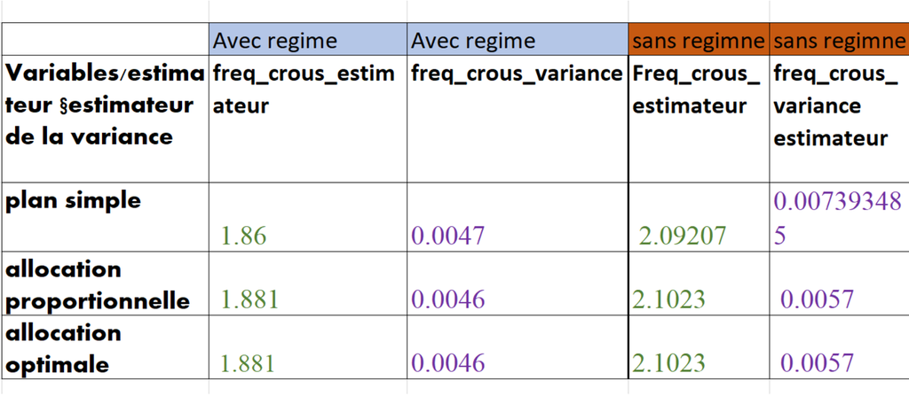

Tableau 1

**Fréquence des repas au Crous :**  
Les résultats montrent que les personnes ayant un régime alimentaire spécifique mangent moins fréquemment au Crous, soit en moyenne **1 à 2 fois par semaine**, comparées à celles n’ayant pas de régime spécifique qui fréquentent le Crous environ **2 fois par semaine au moins**. Cet écart suggère une tendance à manger moins souvent au Crous pour les personnes ayant un régime spécifique.  
Cela est observé quel que soit le type de plan choisi, ce qui traduit que notre estimateur semble fiable.

**Variance de l’estimateur :**  
La variance est plus faible pour les personnes ayant un régime alimentaire spécifique (**0.0046**) par rapport aux personnes sans régime (**0.0057**). Cela indique une plus grande consistance dans les réponses des personnes ayant un régime spécifique. La variabilité des réponses est donc moindre dans ce groupe.ces faibles variances nous rassurent dans la fiabilité de nos estimateurs.

**Interprétation des résultats**

1. **Absence de variables contextuelles importantes :**  
   L’absence de prise en compte de variables contextuelles, telles que la disponibilité d’options alimentaires adaptées (végétarien, végan, sans gluten, etc.) ou la proximité d’autres options alimentaires (restaurants spécialisés, supermarchés), pourrait expliquer pourquoi les moyennes de fréquence des repas au Crous sont relativement proches entre les deux groupes.  
   Par exemple, même si les personnes ayant un régime alimentaire spécifique mangent moins fréquemment au Crous, elles peuvent choisir de manger là-bas de manière occasionnelle, même si l’offre alimentaire ne correspond pas parfaitement à leurs besoins. Cela pourrait réduire l’écart observé entre les deux groupes.

### **Redressement post-stratification**

Nous avons décidé d’appliquer un redressement post-stratification pour cette variable en particulier, car elle répond aux trois critères nécessaires pour effectuer un tel ajustement :

Grâce à nos calculs, nous avons obtenu des estimations redressées qui permettent une représentation plus précise de la population étudiée.

en effet nous obtenons , mu_post = 2.412232 et varpost_ar =0.000567442 pour les personnes n’ayant pas de regime particulier , ce qui suggère que ces personnes fréquence le crous au moins 2 fois par semaine.

### **Absence de redressement pour d’autres variables**

Pour les autres variables, nous avons jugé que le redressement post-stratification n’était pas nécessaire. En effet :

- La **variance de l’estimateur** pour le plan stratifié (avec allocation optimale) est très faible pour ces variables.
- Appliquer un redressement n’aurait pas apporté une amélioration significative dans la précision des estimations, et aurait introduit une complexité inutile.

Ainsi, nous avons opté pour une approche plus simple, tout en maintenant une rigueur méthodologique dans nos analyses.

### **Conclusion**

Ces observations suggèrent que, bien qu’une inadéquation perçue entre les régimes alimentaires et l’offre du Crous puisse exister, elle n’entraîne pas de différences marquées dans la fréquence des repas. Cela souligne que les comportements alimentaires des deux groupes peuvent s’équilibrer grâce à d’autres habitudes alimentaires en dehors du Crous. Le redressement post-stratification a permis de renforcer la robustesse des estimations, offrant une vision plus précise des comportements alimentaires étudiés.

2. Variable d’intérêt: QNPDC ,variable auxiliaire : âge

[figure not shown]

Tableau 2

1. **Interprétation**

**Comparaison des résultats**

**Variance de l’estimateur** :  
La variance de l’estimateur est plus faible pour les personnes n’ayant pas de régime alimentaire spécifique (**environ 0,000051**) que pour celles avec régime (**environ 0,0000735**). Une variance plus faible traduit une plus grande cohérence dans les réponses des personnes n’ayant pas de régime spécifique. Cela peut refléter des comportements alimentaires plus homogènes dans ce groupe, par exemple, une opinion commune sur une mauvaise qualité nutritionnelle des produits vendus au Crous.

**Interprétation des résultats**

1. **Absence de variables contextuelles importantes :**  
   L’absence de prise en compte de variables contextuelles, telles que les préférences alimentaires et les attentes en matière de qualité nutrtionnelle de chaque individu pourrait expliquer pourquoi les moyennes de l’avis sur la qualité nutrionnelle des produits vendus au Crous sont relativement proches entre les deux groupes.  
   Par exemple, même si les personnes n’ayant pas de régime alimentaire spécifique ont insatifaits comme les personnes ayant un régime alimentaire des produits vendus au Crous, elles peuvent avoir des attentes différentes en matière de qualité nutrionnelle. Cela pourrait réduire l’écart observé entre les deux groupes.
2. **Similitudes dans l’opinion sur la qualité nutritionnelle des produits vendus au Crous :**  
   Malgré le fait que les personnes ciblées aient des régimes alimentaires différents, l’avis sur la qualité nutritionnelle des produits vendus au Crous des deux groupes est relativement similaire. Les personnes ayant un régime spécifique pourraient avoir un avis sur la qualité nutrionnelle assez négatif, mais elles pourraient compenser en mangeant seulement le seul produit qui leurs plait au Crous .  
   Ainsi, la similitude de l’opinion sur les produits du Crous pourraient être moins marquée si l’on tient compte de ces autres comportements alimentaires compensatoires. Ce phénomène pourrait expliquer pourquoi la similitude observé.

### **Conclusion**

Les résultats de l’analyse montrent qu’en moyenne, les personnes ayant un régime alimentaire spécifique partagent les mêmes opinions que les personnes n’ayant pas de régime alimentaire particulier. Cependant, cette similitude reste modérée, probablement en raison de facteurs contextuels non pris en compte, comme l’attente de chaque personne en matière de qualité nutrtionnelle.

Ces observations suggèrent que, bien qu’une inadéquation perçue entre les régimes alimentaires et l’offre du Crous puisse exister, elle n’entraîne pas de différences marquées dans l’opinion sur la qualité des produits nutritionnels. Il est important de souligner que les opinions sur les produits alimentaires des deux groupes peuvent varier si l’on prend en compte d’autres critères, comme le fait que des **fausses idées reçues** circulent sur la qualité des produits moins chers, souvent perçus comme étant de mauvaise qualité et moins nutritifs. Ce phénomène pourrait être en partie responsable des **opinions similaires** des deux groupes en matière de qualité nutritionnelle. En outre, le **manque d’éducation nutritionnelle** peut jouer un rôle clé dans cette perception, car les usagers pourraient ne pas être pleinement informés des bénéfices nutritionnels des repas proposés, même à des prix plus abordables.

Ces éléments contextuels, combinés à l’analyse de la fréquence des repas et de l’apport de repas maison, montrent que l’offre alimentaire au Crous pourrait être perçue de manière différente selon les critères individuels, mais ne semble pas influencer fortement l’opinion sur la qualité nutritionnelle des produits.

3. Variable d’intérêt: freq_apport_repas ,variable auxiliaire : statut

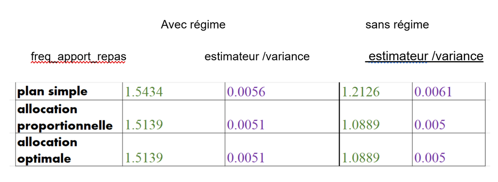

Tableau 3

Nous observons que les personnes ayant un régime alimentaire spécifique ont tendance à apporter plus fréquemment leur nourriture de la maison, contrairement à celles qui n’ont pas de régime particulier. Cette différence pourrait probablement s’expliquer par l’inadéquation ou le manque de choix au niveau des repas proposés au CROUS, obligeant ainsi ces personnes à apporter leurs propres repas.

De plus, nous remarquons que les variances de nos estimateurs, quel que soit le plan, sont relativement faibles. Cela témoigne d’une certaine fiabilité de nos estimateurs, ce qui renforce la robustesse de nos conclusions.

# Bilan

### **1. Fréquence des repas au Crous**

- **Les personnes ayant un régime alimentaire spécifique mangent moins fréquemment au Crous** que celles n’ayant pas de régime spécifique (en moyenne 1 à 2 fois par semaine contre 2 fois par semaine pour les autres).
- **La variance des estimateurs est plus faible** pour les personnes ayant un régime alimentaire spécifique (0.0046), indiquant une plus grande consistance dans leurs réponses.
- **L’absence de variables contextuelles**, telles que la disponibilité d’options alimentaires adaptées, pourrait expliquer pourquoi la différence observée n’est pas plus marquée.
- **Le redressement post-stratification a amélioré les estimations** en montrant que les personnes sans régime fréquentent le Crous au moins deux fois par semaine (μ_post = 2.41, Var_post = 0.00057).

### **2. Avis sur la qualité nutritionnelle des produits vendus au Crous**

- **Les avis sur la qualité nutritionnelle des produits sont similaires** entre les personnes ayant un régime alimentaire spécifique et celles sans régime spécifique, avec une insatisfaction générale des produits proposés.
- **La variance est plus faible** pour les personnes sans régime alimentaire spécifique (0.000051 contre 0.0000735), ce qui suggère que leurs réponses sont plus homogènes.
- **L’absence de prise en compte des préférences individuelles** et des attentes concernant la qualité nutritionnelle pourrait expliquer la similarité des opinions entre les deux groupes.
- **Le manque d’éducation sur la qualité nutritionnelle** et la perception erronée des produits moins chers pourraient être des facteurs explicatifs des opinions similaires entre les deux groupes.

### **3. Fréquence d’apport de repas maison**

- **Les personnes ayant un régime alimentaire spécifique apportent plus fréquemment leur nourriture** que celles sans régime, probablement à cause de l’inadéquation de l’offre au Crous.
- **Les variances sont faibles**, ce qui montre la fiabilité des résultats et la robustesse des conclusions.
- **Les comportements alimentaires compensatoires** (comme l’apport de repas maison) peuvent atténuer l’écart observé dans la fréquence des repas au Crous.

### **Conclusion générale**

En conclusion, notre analyse des pratiques alimentaires des usagers sur le campus de Villetaneuse met en lumière plusieurs observations intéressantes.

- **Les personnes ayant un régime alimentaire spécifique** mangent effectivement **moins fréquemment au Crous** que celles sans régime particulier. Cependant, cet écart reste relativement modéré et pourrait être influencé par des facteurs contextuels non pris en compte dans notre étude, comme la diversité des options alimentaires disponibles en dehors du Crous.
- **Les opinions sur la qualité nutritionnelle des produits vendus au Crous** sont similaires entre les deux groupes, bien que les personnes avec un régime spécifique puissent avoir des attentes différentes en matière de qualité nutritionnelle. Il est également possible que des facteurs externes, comme des idées reçues sur les produits alimentaires, expliquent cette similarité dans les avis.
- **Les personnes ayant un régime alimentaire spécifique apportent plus fréquemment leur nourriture**, ce qui pourrait refléter un manque d’adaptation de l’offre alimentaire du Crous à leurs besoins spécifiques.

Ainsi, bien qu’une **inadéquation perçue entre les régimes alimentaires et l’offre du Crous** puisse expliquer en partie la **fréquence réduite des repas au Crous**, cette hypothèse ne peut être pleinement validée sans prendre en compte d’autres paramètres contextuels et comportementaux. Cependant, les résultats suggèrent que des facteurs compensatoires (comme l’apport de repas maison) et des opinions partagées sur la qualité nutritionnelle des produits au Crous peuvent contribuer à expliquer la faible fréquence des repas des personnes ayant un régime alimentaire spécifique.

Pour répondre à la sous-problématique, **il semble que les personnes ayant un régime alimentaire particulier mangent moins souvent au Crous**, mais cet écart n’est pas entièrement expliqué par l’offre alimentaire inadéquate. D’autres comportements alimentaires compensatoires et des perceptions similaires de la qualité des repas peuvent également jouer un rôle important dans la dynamique observée.

# Annexes :